# Diagnostic Tests

September 2021

## Diagnostic tests

## Data

```r
library(AER)
data(Journals, package = "AER")
journals <- Journals %>%
  mutate(citeprice = price/citations) %>%
  select(subs, price, citeprice)
glimpse(journals)
```

```
## Rows: 180
## Columns: 3
## $ subs      <int> 14, 59, 17, 2, 96, 15, 14, 202, 46, 46, 57, 125, 30, 62, 16,~
## $ price     <int> 123, 20, 443, 276, 295, 344, 90, 242, 226, 262, 279, 165, 24~
## $ citeprice <dbl> 5.8571, 0.9091, 20.1364, 12.5455, 12.2917, 14.3333, 3.7500, ~
```

- The Breusch-Pagan test

```r
jour_lm <- lm(log(subs) ~ log(citeprice), data = journals)
# library(lmtest)
bptest(jour_lm)
```

```
##
##  studentized Breusch-Pagan test
##
## data:  jour_lm
## BP = 9.8, df = 1, p-value = 0.002
```

```r
bptest(cps_lm)
```

```
##
##  studentized Breusch-Pagan test
##
## data:  cps_lm
## BP = 616, df = 4, p-value <0.0000000000000002
```

- The Goldfeld-Quandt test

```r
# library(lmtest)
gqtest(jour_lm, order.by = ~ citeprice, data = journals)
```

```
##
##  Goldfeld-Quandt test
##
## data:  jour_lm
## GQ = 1.7, df1 = 88, df2 = 88, p-value = 0.007
## alternative hypothesis: variance increases from segment 1 to 2
```

## Testing the functional form.

- Ramsey’s RESET
- Misspecification of functional form (by omitting relevant variables).
- Let’s assess whether second and third powers of \(log(citeprice)\) can significantly improve the model.

```r
# library(lmtest)
reset(jour_lm)
```

```
##
##  RESET test
##
## data:  jour_lm
## RESET = 1.4, df1 = 2, df2 = 176, p-value = 0.2
```

- The result is clearly non-significant, and hence no misspecification can be detected in this direction.

## Multiple models in `stargazer` with heteroskedasticity-robust standard errors.

## Data

```r
library(AER)
library(tidyverse)
library(stargazer)

data(CASchools, package = "AER")
caschool <- CASchools

caschool <- mutate(caschool, str = students/teachers,
         testscr = (math + read)/2)
glimpse(caschool)
```

```
## Rows: 420
## Columns: 16
## $ district    <chr> "75119", "61499", "61549", "61457", "61523", "62042", "685~
## $ school      <chr> "Sunol Glen Unified", "Manzanita Elementary", "Thermalito ~
## $ county      <fct> Alameda, Butte, Butte, Butte, Butte, Fresno, San Joaquin, ~
## $ grades      <fct> KK-08, KK-08, KK-08, KK-08, KK-08, KK-08, KK-08, KK-08, KK~
## $ students    <dbl> 195, 240, 1550, 243, 1335, 137, 195, 888, 379, 2247, 446, ~
## $ teachers    <dbl> 10.90, 11.15, 82.90, 14.00, 71.50, 6.40, 10.00, 42.50, 19.~
## $ calworks    <dbl> 0.5102, 15.4167, 55.0323, 36.4754, 33.1086, 12.3188, 12.90~
## $ lunch       <dbl> 2.041, 47.917, 76.323, 77.049, 78.427, 86.956, 94.624, 100~
## $ computer    <dbl> 67, 101, 169, 85, 171, 25, 28, 66, 35, 0, 86, 56, 25, 0, 3~
## $ expenditure <dbl> 6385, 5099, 5502, 7102, 5236, 5580, 5253, 4566, 5356, 5036~
## $ income      <dbl> 22.690, 9.824, 8.978, 8.978, 9.080, 10.415, 6.577, 8.174, ~
## $ english     <dbl> 0.000, 4.583, 30.000, 0.000, 13.858, 12.409, 68.718, 46.95~
## $ read        <dbl> 691.6, 660.5, 636.3, 651.9, 641.8, 605.7, 604.5, 605.5, 60~
## $ math        <dbl> 690.0, 661.9, 650.9, 643.5, 639.9, 605.4, 609.0, 612.5, 61~
## $ str         <dbl> 17.89, 21.52, 18.70, 17.36, 18.67, 21.41, 19.50, 20.89, 19~
## $ testscr     <dbl> 690.8, 661.2, 643.6, 647.7, 640.9, 605.6, 606.8, 609.0, 61~
```

We shall consider the following models and graphically inspect the correlation and summarise all the regression results in a table. \[ \begin{align*} \text{(I) }\text{testscr} &= \beta_0 + \beta_1\text{str} + u\\ \text{(II) }\text{testscr} &= \beta_0 + \beta_1\text{str} + \beta_2\text{english} + u\\ \text{(III) }\text{testscr} &= \beta_0 + \beta_1\text{str} + \beta_2\text{english} + \beta_3\text{lunch} + u\\ \text{(IV) }\text{testscr} &= \beta_0 + \beta_1\text{str} + \beta_2\text{english} + \beta_3\text{calworks} + u\\ \text{(V) }\text{testscr} &= \beta_0 + \beta_1\text{str} + \beta_2\text{english} + \beta_3\text{lunch} + \beta_4\text{calworks} + u\\ \end{align*} \]

where, `testscr`- test score `str` - student-teacher ratio `english` - percentage of english learners `lunch` - percentage of students that qualify for a free or subsidised lunch due to family incomes below a certain threshold. `calworks` - percentage of students qualifying for the *calworks* income assistance programme.

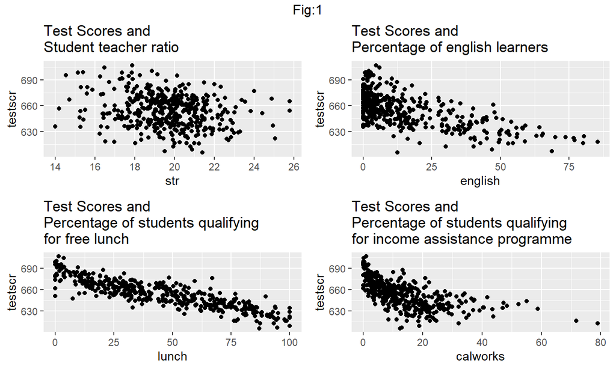

```r
library(gridExtra)
p1 <- ggplot(caschool)+
  geom_point(aes(str, testscr)) +
  labs(title = "Test Scores and\nStudent teacher ratio")
p2 <- ggplot(caschool)+
  geom_point(aes(english, testscr)) +
  labs(title = "Test Scores and\nPercentage of english learners")
p3 <- ggplot(caschool)+
  geom_point(aes(lunch, testscr)) +
  labs(title = "Test Scores and\nPercentage of students qualifying\nfor free lunch")
p4 <- ggplot(caschool)+
  geom_point(aes(calworks, testscr))+
  labs(title = "Test Scores and\nPercentage of students qualifying \nfor income assistance programme")

grid.arrange(p1, p2, p3, p4, nrow = 2, ncol = 2, top = "Fig:1")
```

- Using colours

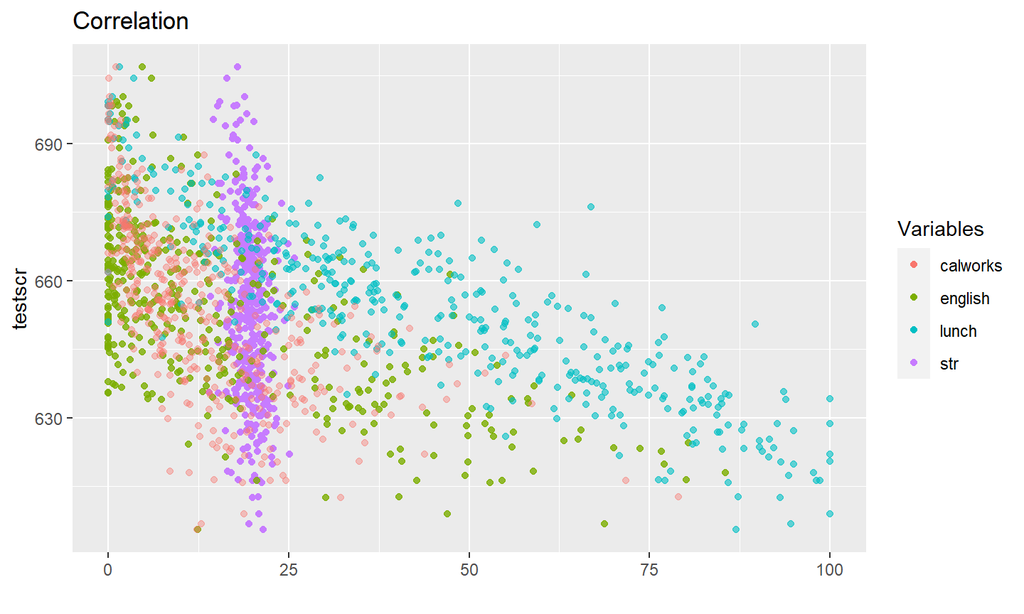

```r
caschool %>%
  ggplot(aes(str, testscr))+
  geom_point(aes(colour = 'str'), alpha = 1)+
  geom_point(aes(x = english, colour = 'english'), alpha = 0.8) +
  geom_point(aes(x = lunch, colour = 'lunch'), alpha = 0.6)+
  geom_point(aes(x = calworks, colour = 'calworks'), alpha = 0.4) +
  labs(x = "",
       colour = "Variables",
       title = "Correlation")
```

-Using plotting characters (shapes)

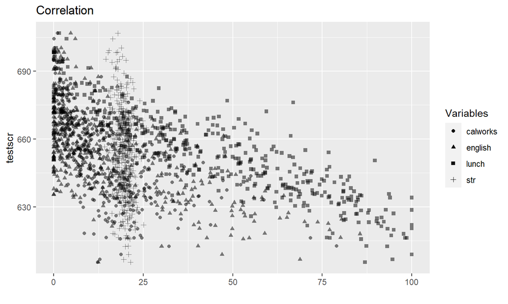

```r
caschool %>%
  ggplot(aes(str, testscr))+
  geom_point(aes(shape = 'str'), alpha = 0.5)+
  geom_point(aes(x = english, shape = 'english'), alpha = 0.5) +
  geom_point(aes(x = lunch, shape = 'lunch'), alpha = 0.5)+
  geom_point(aes(x = calworks, shape = 'calworks'), alpha = 0.5) +
  labs(x = "",
       shape = "Variables",
       title = "Correlation")
```

- Non-linear model

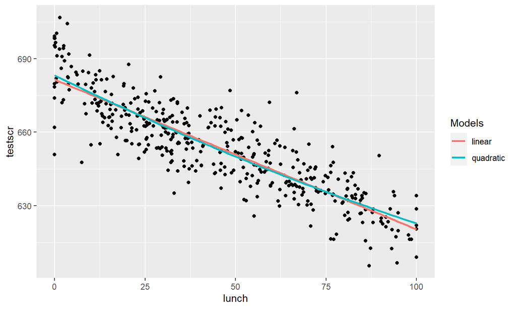

```r
ggplot(caschool, aes(x = lunch, y = testscr))+
  geom_point()+
  geom_smooth(aes(colour = "linear"),formula = y ~ x, method = "lm", se =FALSE)+
  geom_smooth(aes(colour = "quadratic"),formula = y ~ x + I(x^2), method = "lm", se = FALSE)+
  labs(colour = "Models")
```

## Heteroskedasticity-robust standard errors.

Consistent estimation of \(\sigma_{\hat\beta_1}\) under heteroskedasticity (**Eicker–Huber–White standard errors**): \[ SE(\hat\beta_1) = \sqrt{\frac{1}{n}.\frac{\frac{1}{n}\sum_{i=1}^{n}(X_i - \overline{X})^2\hat{u_i}^2}{\Big[ \frac{1}{n}\sum_{i=1}^{n}(X_i - \overline{X})^2\Big]^2}} \]

Degrees of freedom correction and considered by MacKinnon & White (1985), The difference is that we multiply by \(\frac{1}{n-2}\) in the numerator of the previous equation. \[ SE(\hat\beta_1)_{HC1} = \sqrt{\frac{1}{n}.\frac{\frac{1}{n-2}\sum_{i=1}^{n}(X_i - \overline{X})^2\hat{u_i}^2}{\Big[ \frac{1}{n}\sum_{i=1}^{n}(X_i - \overline{X})^2\Big]^2}} \]

- variance-covariance heteroskedasticity-consistent matrix estimation using `vcovHC()` in the `sandwich` package.

```r
lm_model1 <- lm(testscr ~ str, data = caschool)
vcovHC(lm_model1, type = "HC1")
```

```
##             (Intercept)     str
## (Intercept)     107.420 -5.3639
## str              -5.364  0.2699
```

```r
class(vcovHC(lm_model1, type = "HC1"))
```

```
## [1] "matrix" "array"
```

- We are interested in the square root of the diagonal elements of this matrix, i.e., the standard error estimates.

```r
robust_se <- sqrt(diag(vcovHC(lm_model1, type = "HC1")
))
robust_se
```

```
## (Intercept)         str
##     10.3644      0.5195
```

```r
# models
I <- lm(testscr ~ str, data = caschool)
II <- lm(testscr ~ str + english, data = caschool)
III <- lm(testscr ~ str + english + lunch, data = caschool)
IV <- lm(testscr ~ str + english + calworks, data = caschool)
V <- lm(testscr ~ str + english + lunch + calworks, data = caschool)

# gather all the robust standard error values in a list
robust_se1 <- list(
  sqrt(diag(sandwich::vcovHC(I, type = "HC1"))),
  sqrt(diag(sandwich::vcovHC(II, type = "HC1"))),
  sqrt(diag(sandwich::vcovHC(III, type = "HC1"))),
  sqrt(diag(sandwich::vcovHC(IV, type = "HC1"))),
  sqrt(diag(sandwich::vcovHC(V, type = "HC1")))
)

## use the `stargazer()` function to represent the output in a tabular form
stargazer::stargazer(I, II, III, IV, V, type = "text",
                     title = "Analysis of caschool dataset.",
                     se = robust_se1, digits = 3,
                     column.labels = c("I", "II", "III", "IV", "V"),
                     column.sep.width = "1pt",
                     notes = "Heteroskedasticity robust standard errors are given in parentheses under coefficients.",
                     notes.append = TRUE)
```

```
##
## Analysis of caschool dataset.
## ===============================================================================================================================================
##                                                                         Dependent variable:
##                     ---------------------------------------------------------------------------------------------------------------------------
##                                                                               testscr
##                                I                       II                      III                       IV                       V
##                               (1)                     (2)                      (3)                      (4)                      (5)
## -----------------------------------------------------------------------------------------------------------------------------------------------
## str                        -2.280***                -1.101**                -0.998***                -1.308***                -1.014***
##                             (0.519)                 (0.433)                  (0.270)                  (0.339)                  (0.269)
##
## english                                            -0.650***                -0.122***                -0.488***                -0.130***
##                                                     (0.031)                  (0.033)                  (0.030)                  (0.036)
##
## lunch                                                                       -0.547***                                         -0.529***
##                                                                              (0.024)                                           (0.038)
##
## calworks                                                                                             -0.790***                  -0.048
##                                                                                                       (0.068)                  (0.059)
##
## Constant                  698.900***               686.000***               700.100***               698.000***               700.400***
##                            (10.360)                 (8.728)                  (5.568)                  (6.920)                  (5.537)
##
## -----------------------------------------------------------------------------------------------------------------------------------------------
## Observations                  420                     420                      420                      420                      420
## R2                           0.051                   0.426                    0.775                    0.629                    0.775
## Adjusted R2                  0.049                   0.424                    0.773                    0.626                    0.773
## Residual Std. Error    18.580 (df = 418)       14.460 (df = 417)         9.080 (df = 416)        11.650 (df = 416)         9.084 (df = 415)
## F Statistic         22.570*** (df = 1; 418) 155.000*** (df = 2; 417) 476.300*** (df = 3; 416) 234.600*** (df = 3; 416) 357.100*** (df = 4; 415)
## ===============================================================================================================================================
## Note:                                                                                                               *p<0.1; **p<0.05; ***p<0.01
##                                                          Heteroskedasticity robust standard errors are given in parentheses under coefficients.
```